# Feature Analyis

*This notebook mainly shows the distribution of the target feature and the relation between the target and the most critical features*

Load the required packages and the dataset

```r
require(MASS)
require(goftest)

load("../data/data_final/data_final.RData")
```

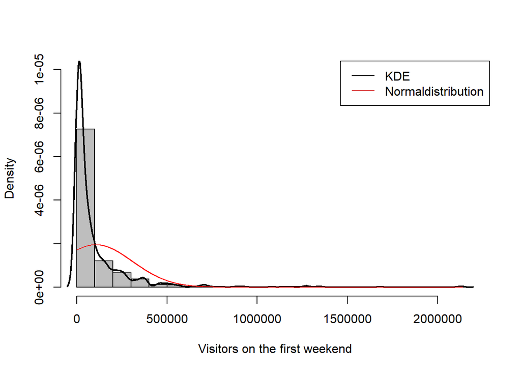

```r
truehist(data = data_final$Besucher_wochenende1, col = "grey", ylim = c(0, 0.00001),
         xlab = "Visitors on the first weekend", ylab = "Density")
lines(x = density(data_final$Besucher_wochenende1), col = "black", lwd = 2)
grid = seq(from = 0, to = max(data_final$Besucher_wochenende1), by = 10)
lines(x = grid, y = dnorm(x = grid, mean = mean(data_final$Besucher_wochenende1),
                          sd = sd(data_final$Besucher_wochenende1)), col = "red")
legend("topright", legend = c("KDE", "Normaldistribution"), col = (c("black", "red3")), lty = 1)
```

The target obviously isn’t normal distributed. Whereas, the logarithmic target seems to follow a normal distributionquite well.

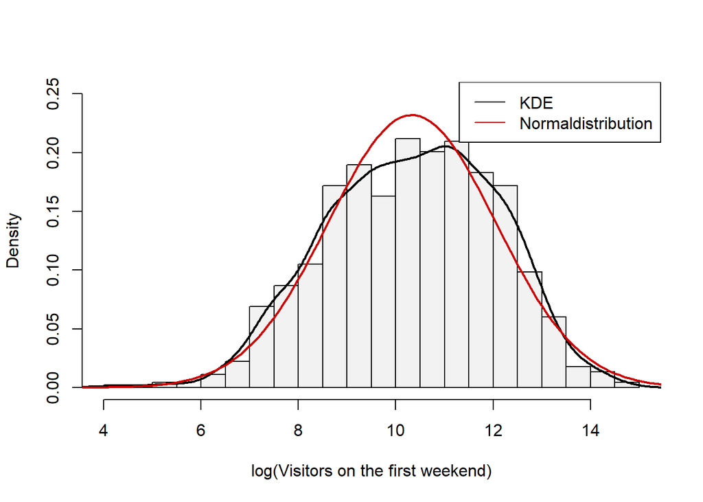

```r
truehist(data = data_final$Besucher_wochenende1_log, col = "grey95", ylim = c(0.00, 0.25), ylab = "Density",
         xlab = "log(Visitors on the first weekend)")
lines(x = density(data_final$Besucher_wochenende1_log), col = "black", lwd = 2)
grid = seq(from = 0, to = max(data_final$Besucher_wochenende1_log) + 1, by = 0.1)
lines(x = grid, y = dnorm(x = grid, mean = mean(data_final$Besucher_wochenende1_log),
                          sd = sd(data_final$Besucher_wochenende1_log)), col = "red3", lwd = 2)
legend("topright", legend = c("KDE", "Normaldistribution"), col = (c("black", "red3")), lty = 1)
```

The following tests check for normal distribution of the untransformed target:

```r
fit_normal = fitdistr(x = data_final$Besucher_wochenende1, densfun = "normal")
# Kolmogorov-Smirnov-Test:
ks.test(x = data_final$Besucher_wochenende1, y = "pnorm", mean = fit_normal$estimate[1], sd = fit_normal$estimate[2],
        exact = TRUE)
```

```
##
##  One-sample Kolmogorov-Smirnov test
##
## data:  data_final$Besucher_wochenende1
## D = 0.30346, p-value = 1.388e-14
## alternative hypothesis: two-sided
```

```r
# Anderson-Darling-Test:
ad.test(x = data_final$Besucher_wochenende1, null = "pnorm", mean = fit_normal$estimate[1], sd = fit_normal$estimate[2])
```

```
##
##  Anderson-Darling test of goodness-of-fit
##  Null hypothesis: Normal distribution
##  with parameters mean = 105145.583705357, sd = 204264.868494528
##
## data:  data_final$Besucher_wochenende1
## An = Inf, p-value = 6.696e-07
```

```r
# Cramer-von-Mises-Test:
cvm.test(x = data_final$Besucher_wochenende1, null = "pnorm",
         mean = fit_normal$estimate[1], sd = fit_normal$estimate[2])
```

```
##
##  Cramer-von Mises test of goodness-of-fit
##  Null hypothesis: Normal distribution
##  with parameters mean = 105145.583705357, sd = 204264.868494528
##
## data:  data_final$Besucher_wochenende1
## omega2 = 24.446, p-value = 1.443e-06
```

Let’s have a look on the logarithmic target feature:

```r
fit_lognormal = fitdistr(x = data_final$Besucher_wochenende1, densfun = "lognormal")
# Kolmogorov-Smirnov-Test:
ks.test(x = data_final$Besucher_wochenende1_log, y = "pnorm",
        mean = fit_lognormal$estimate[1], sd = fit_lognormal$estimate[2], exact = TRUE)
```

```
##
##  One-sample Kolmogorov-Smirnov test
##
## data:  data_final$Besucher_wochenende1_log
## D = 0.037118, p-value = 0.1651
## alternative hypothesis: two-sided
```

```r
# Anderson-Darling-Test:
ad.test(x = data_final$Besucher_wochenende1_log, null = "pnorm",
        mean = fit_lognormal$estimate[1], sd = fit_lognormal$estimate[2])
```

```
##
##  Anderson-Darling test of goodness-of-fit
##  Null hypothesis: Normal distribution
##  with parameters mean = 10.3307815957388, sd = 1.7178039411094
##
## data:  data_final$Besucher_wochenende1_log
## An = 1.8728, p-value = 0.108
```

```r
# Cramer-von-Mises-Test:
cvm.test(x = data_final$Besucher_wochenende1_log, null = "pnorm",
         mean = fit_lognormal$estimate[1], sd = fit_lognormal$estimate[2])
```

```
##
##  Cramer-von Mises test of goodness-of-fit
##  Null hypothesis: Normal distribution
##  with parameters mean = 10.3307815957388, sd = 1.7178039411094
##
## data:  data_final$Besucher_wochenende1_log
## omega2 = 0.30105, p-value = 0.1342
```

In this case all of the tests have a p-value above 0.05, which leads to an acceptance of the Null hypothesis and confirms the impressions of the upper plots. The target feature seems to follow a log-normal distribution to a statistically siginifcant degree.

A final test should also take the gamma distribution into consideration, which seems to fit the distribution of the target very well if one takes a look at the following plot:

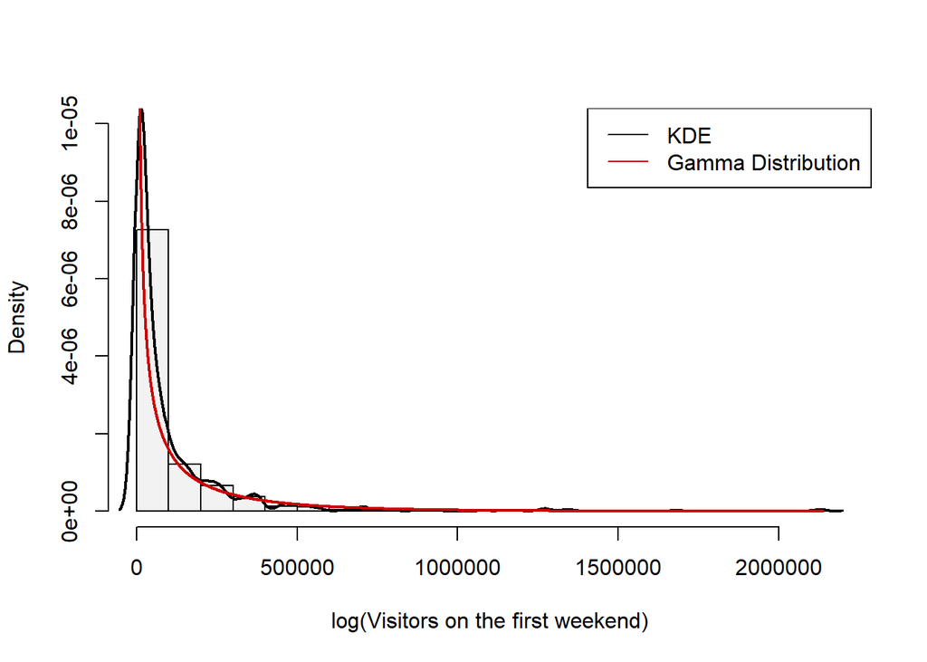

```r
shape = mean(data_final$Besucher_wochenende1) ^ 2 / var(data_final$Besucher_wochenende1)
scale = var(data_final$Besucher_wochenende1) / mean(data_final$Besucher_wochenende1)
truehist(data = data_final$Besucher_wochenende1, col = "grey95", ylim = c(0.00, 0.00001), ylab = "Density",
         xlab = "log(Visitors on the first weekend)")
lines(x = density(data_final$Besucher_wochenende1), col = "black", lwd = 2)
grid = seq(from = 0, to = max(data_final$Besucher_wochenende1) + 1, by = 10)
lines(x = grid, y = dgamma(x = grid, shape = shape, scale = scale), col = "red3", lwd = 2)
legend("topright", legend = c("KDE", "Gamma Distribution"), col = (c("black", "red3")), lty = 1)
```

Applying the three tests results in the following ouputs:

```r
shape = mean(data_final$Besucher_wochenende1) ^ 2 / var(data_final$Besucher_wochenende1)
scale = var(data_final$Besucher_wochenende1) / mean(data_final$Besucher_wochenende1)
fit_gamma = fitdistr(x = data_final$Besucher_wochenende1, densfun = "gamma", start = list(shape = shape, scale = scale))
# Kolmogorov-Smirnov-Test:
ks.test(x = data_final$Besucher_wochenende1, y = "pgamma", shape = fit_gamma$estimate[1], scale = fit_gamma$estimate[2],
        exact = TRUE)
```

```
##
##  One-sample Kolmogorov-Smirnov test
##
## data:  data_final$Besucher_wochenende1
## D = 0.13046, p-value = 1.034e-13
## alternative hypothesis: two-sided
```

```r
# Anderson-Darling-Test:
ad.test(x = data_final$Besucher_wochenende1, null = "pgamma",
        shape = fit_gamma$estimate[1], scale = fit_gamma$estimate[2])
```

```
##
##  Anderson-Darling test of goodness-of-fit
##  Null hypothesis: Gamma distribution
##  with parameters shape = 0.399973613325514, scale = 397265.905364349
##
## data:  data_final$Besucher_wochenende1
## An = 34.643, p-value = 6.696e-07
```

```r
# Cramer-von Mises-Test:
cvm.test(x = data_final$Besucher_wochenende1, null = "pgamma",
         scale = fit_gamma$estimate[1], shape = fit_gamma$estimate[2])
```

[output not shown]

Therefore, for all further descriptive analysis the logarithmic target feature will be used.

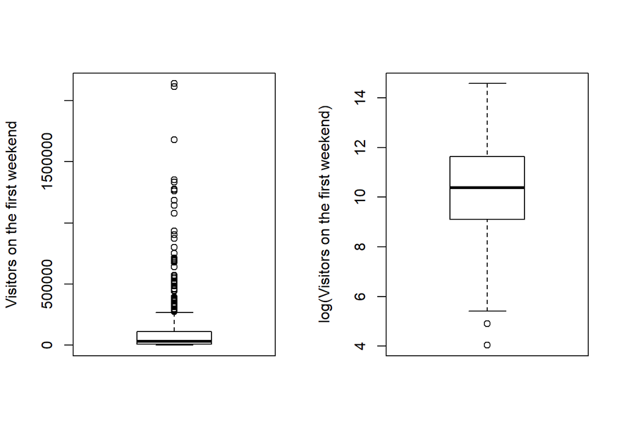

```r
# Boxlpots
par(mfrow = c(1, 2))
boxplot(x = data_final$Besucher_wochenende1, ylab = "Visitors on the first weekend")
boxplot(x = data_final$Besucher_wochenende1_log, ylab = "log(Visitors on the first weekend)")
```

```r
par(mfrow = c(1, 1))
```

Also the boxplots of the untranformed and the logarithmic target varaible depict a much more balanced image of the logarithmic feature with much less outliers than the untransformed target.

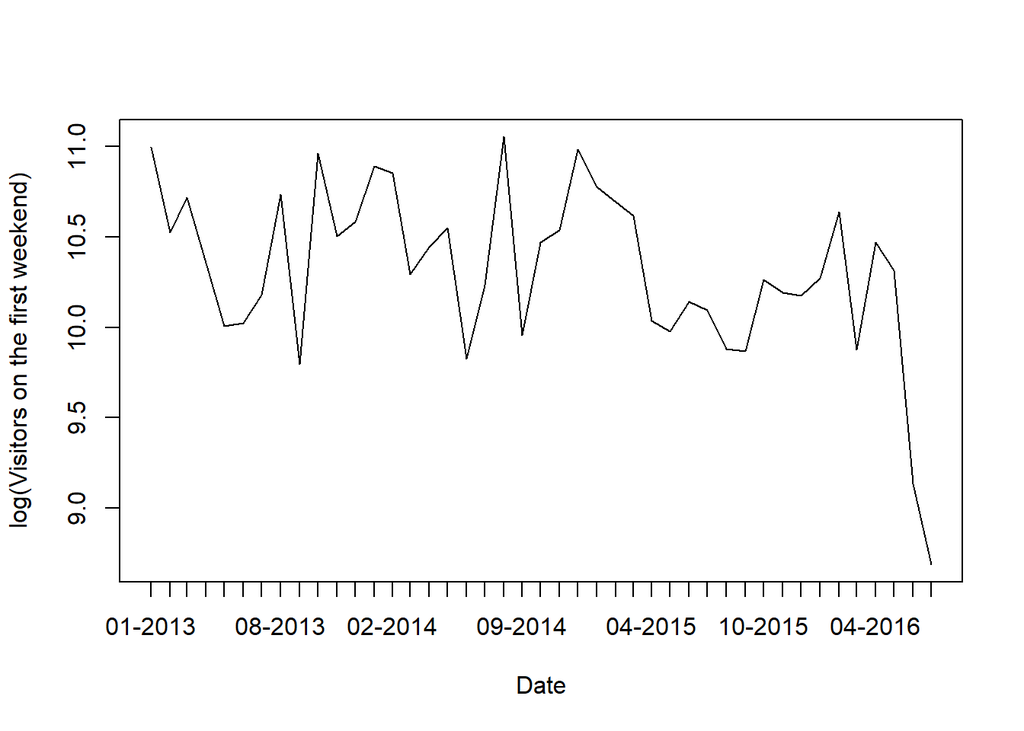

```r
t_mon = as.POSIXlt(data_final$Kinostart)$mon + 1
t_y = as.POSIXlt(data_final$Kinostart)$year + 1900
t = as.Date(paste0(t_mon, "-", t_y, "01"), format = "%m-%Y%d")
tmp = aggregate(data_final$Besucher_wochenende1_log, by = list(t), mean)
colnames(tmp) = c("Date", "Visitors_log")
plot(tmp$Visitors_log ~ tmp$Date, type = "l", xaxt = "n", ylab =  "log(Visitors on the first weekend)", xlab = "Date")
axis.Date(side = 1, at = tmp$Date, format = "%m-%Y")
```

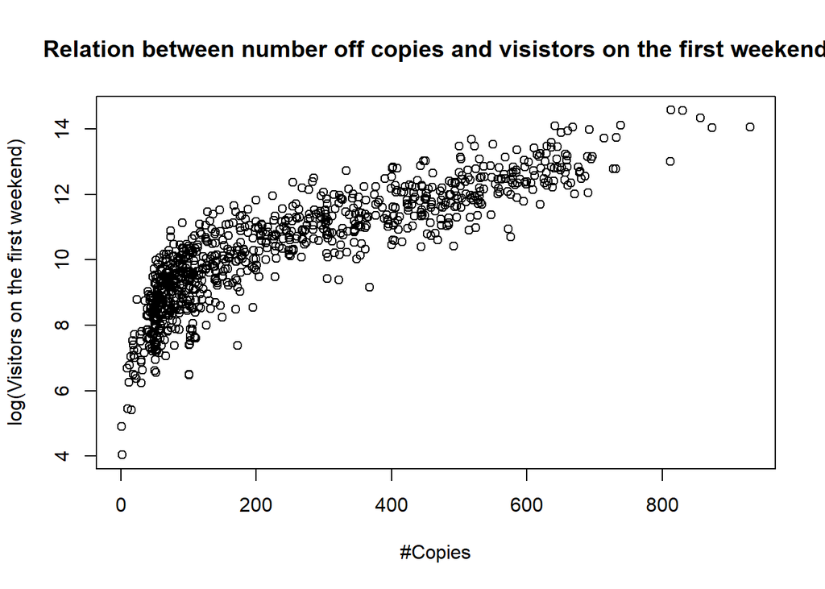

```r
plot(x = data_final$Kopien, y = data_final$Besucher_wochenende1_log,
     main = "Relation between number off copies and visistors on the first weekend", xlab = "#Copies",
     ylab = "log(Visitors on the first weekend)")
```

The upper plot shows a clear relation between number of copies and the target feature. Obviously, this relation is not linear which should be taken into account if one includes this feature into her model.

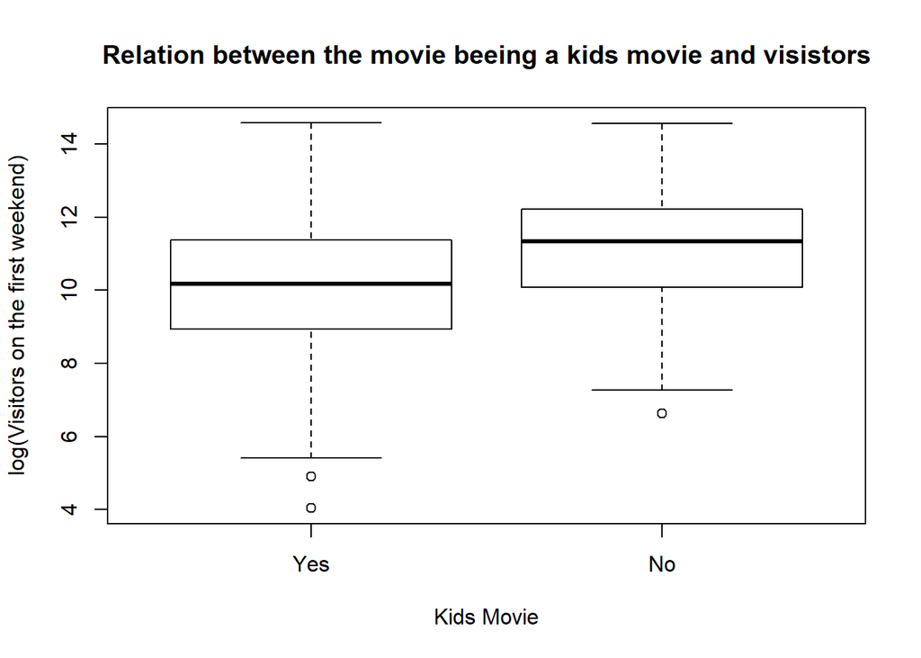

```r
plot(x = data_final$Kinderfilm, y = data_final$Besucher_wochenende1_log,
     main = "Relation between the movie beeing a kids movie and visistors",
     ylab = "log(Visitors on the first weekend)", xlab = "Kids Movie",  names = c("Yes", "No"))
```

Also there seems to be a relation between the movie beeing a Kids Movie or not. Whereby, Kids Movies usually attract less visitors that Non Kids Movies.

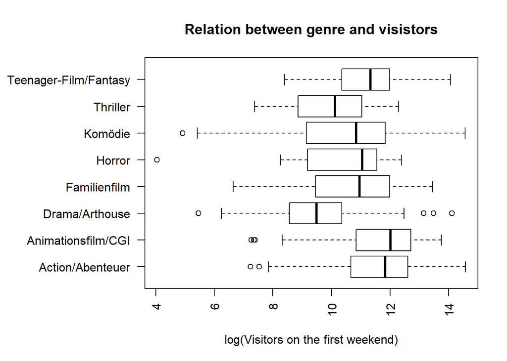

```r
par(mar = c(5, 10, 4, 2))
plot(x = data_final$Genre_Prognose, y = data_final$Besucher_wochenende1_log, horizontal=TRUE, las=2,
     main = "Relation between genre and visistors", xlab = "log(Visitors on the first weekend)", ylab = "")
```

If one takes a look at the relation between the visitors of a movie an its genre two points are highly remarkable: Thrillers and especially Drama and Arthouse movies seem to attract much less visitors than the other movie genres. On the other hand Action/Adventure movies and CGI movies seem to attract much more than the average movie. The remaining genres seem to attract an average number ob people with almost no outliers in the tranformed target.

The plot below shows the relation between the category of the stuio and the target feature. Unsurprisingly bigger studios tent to release movies which attract a greater amount of visitors than the smaller independent studios.

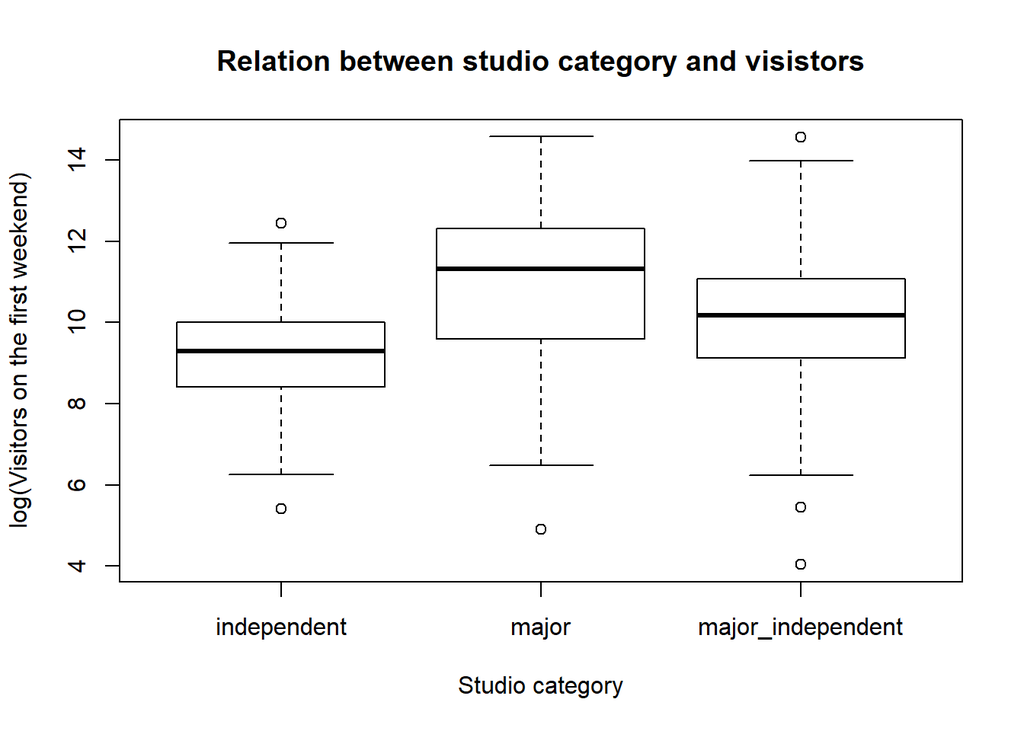

```r
plot(x = data_final$Verleiherkategorie, y = data_final$Besucher_wochenende1_log,
     main = "Relation between studio category and visistors",
     ylab = "log(Visitors on the first weekend)", xlab = "Studio category")
```